# Credit Risk

Kevin Crotty  
BUSI 448: Investments

## Where are we?

**Last time**:

- More interest rate risk
- Convexity
- Callable bonds

**Today**:

- Credit risk
- Credit ratings

## Credit risk

**Credit risk**: the risk that the issuer of a bond (borrower) will not pay back all or part of the promised cash flows.

Issuers with credit risk:

- Corporations
- Households
- Governments

# Credit ratings

## Investment-grade versus high-yield

Moody’s

S&P + Fitch

Investment Grade

- Aaa
- Aa
- A
- Baa
- AAA
- AA
- A
- BBB

High-Yield (Junk)

- Ba
- B
- $\leq$ Caa
- BB
- B
- $\leq$ CCC
- **Higher ratings generally mean less default risk.**
- There are + and - notches for the ratings above.

## Purposes of ratings

- Proxy for credit risk
- Regulation
  - Ex: Capital req’s are often tied to ratings
- Contracting
  - Downgrades may trigger contract clauses

# Modeling corporate credit

## Modeling corporate credit

- Why would a 5-year IBM bond have a different yield from a 5-year AAPL bond?
  - industry differences
  - firm-specific information
  - capital structure

Let’s take a look at some data.

## Regression analysis #1

$$y_{it} = \beta_0 + \beta_1 \cdot \text{ttm}_{it} + \beta_2 \cdot \text{rating}_{it} + \varepsilon_{it}$$

- rating is numeric 1, 2, 3, …
  - we might want to do this differently

## Average yield by ratings class

- Let’s calculate the average yield within each ratings class.
- What should we expect to see as credit ratings decline?

Code to average by ratings class:

```python
df.groupby('RATING_CAT')['ytm'].aggregate(['mean','count'])
```

## Regression analysis #2

- It’s possible that yield-ratings relation will be non-linear.
- One way to capture this is to add dummy variables for each ratings bin:

$$y_{it} = \beta_0 + \beta_1 \cdot \text{ttm}_{it} + \sum_{k=AA,A,...} \beta_k \cdot 1[\text{rating}_{it}=k] + \varepsilon_{it}$$

Code to generate dummy variables:

```python
rating_dummies = pd.get_dummies(df.RATING_CAT)
df = df.merge(rating_dummies,left_index=True,right_index=True)
```

## Regression versus within-class averages

- How do the within-class averages compare to the dummy-variable regressions?
- NOTE: this would be *exact* if we hadn’t controlled for time-to-maturity.

## For a risky bond, YTM $\neq$ expected return!

- YTM: IRR of a bond based on **promised** cash flows.

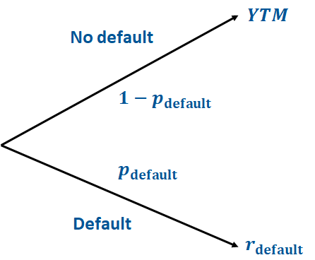

$$\begin{align*}
E[r] =& (1-p_{\text{default}})\cdot YTM \\
&+ p_{\text{default}}\cdot r_{\text{default}}
\end{align*}$$

**YTM overestimates expected returns for risky bonds.**

# Credit Spreads

## Yield Spreads

- Bonds with credit risk are often quoted as an interest rate spread relative to some benchmark rate
  - Treasury of same maturity or a interest rate swap

$$\text{Spread} = YTM_{\text{risky}} - YTM_{\text{maturity-matched risk-free}}$$

- Spread is related to the default probability times the expected loss given default (in risk-neutral terms).
  - $\uparrow$ in probability of default increases spread
  - $\uparrow$ in expected loss given default increases spread
- Let’s look at an example on the [dashboard](https://learn-investments.rice-business.org/fixed-income/creditspreads)

# CDS

## Credit default swaps

**Credit default swaps**: an insurance contract against default by a risky borrower

*Two cash flow streams*:

1. CDS buyer pays CDS seller a period payment (**premium**)
2. If firm defaults, the CDS seller pays the buyer the bond’s par value less the bond’s market value.
- CDS contracts are intended to make an investor in an issuer’s debt whole in the case of default.

## CDS cash flows

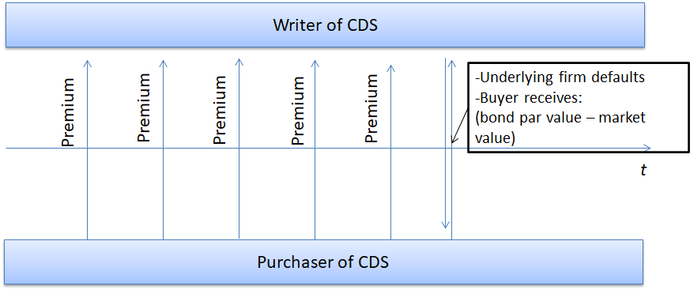

## No-arbitrage relation

- There is a no-arbitrage relation between a corporate bond, risk-free debt, and a CDS.
- The cash flows from owning a risky bond + CDS should be the same as owning a risk-free bond.
- The **Law of One Price** says that two portfolios that generate the same cash flows in the future should have the same price today!
  - This implies that:

$$\text{Bond Yield Spread} = \text{CDS spread}$$

## Cash flows with and without default

Let $R<100$ denote the recovery for a defaulted bond.

With default, the payoffs are:

| Risky Bond | Risk-free Bond | CDS |
| --- | --- | --- |
| R | 100 | 100-R |

With no default, the payoffs are:

| Risky Bond | Risk-free Bond | CDS |
| --- | --- | --- |
| 100 | 100 | 0 |

- Risky Bond + CDS provides $100 either way!

## Uses of CDS

- Hedging of credit risk by long bond investors
- Speculation
  - buy CDS if you think an issuer will default
  - sell CDS to collect premiums

## Economic debates

- *Empty creditor problem*:
  - is it good for bondholders to *not* have exposure to firm’s credit risk?
  - will these investors monitor effectively?
- *Counterparty risk*:
  - CDS writers could be on the hook for a large amount in the event an issuer defaults. Will they be good for it?
- *Legal questions*:
  - What constitutes a default?

# For next time: Asset Management

[figure not shown]